# ESG indicators

An Analysis of availability

2019-08-08

## Executive Summary

This paper analyzed a set of 123 ESG investment related indicators in order to provide a comprehensive overview of the sources, timeliness and statistical methods through which the selected indicators have been created. We have identified a high number of indicators, 26, that are no longer updated in the WDI database or that do not belong to the WDI database. The social indicators appear to be the most robust indicators having the least number of indicators that come with missing data on key variables of interest for this paper, followed by governance and environmental indicators. Most of the indicators are produced by international organization making them of high confidence and generally very robust. Further analysis is recommended into drafting a series of transparent criteria on how these indicators have been selected is recommended together with an assessment of the most used indicators as to allow for improvements to be focused on those indicators with the highest ESG investment impact.

# 1 Introduction

This document aims at providing an overview of the indicators curated and disseminated by the World Bank Group that are relevant for ESG (Environmental, Social, Governance) investment. The work has been conducted by assembling a metadata database on indicators, interviewing data managers, and analyzing the set of 123 identified indicators and their corresponding metadata. We start with a detailed overview of the methodology used to analyze the dataset and we continue with providing a set of insights on sources, processing entities and dissemination of these indicators and the frequency of their updates and release.

# 2 ESG metadata description

The first part of the paper aims at providing an overview of the methodology used for the analysis and a description of the database assembled for the analysis. The second part of the paper aims at providing analytical insights on the ESG indicators with a focus on measures to improve the timeliness and management of ESG relevant indicators.

## 2.1 Methodology

The 123 indicators identified as relevant for ESG investment come from the World Bank databases, mainly from the World Development Indicators database. In order to have a complete picture of the indicators, we assembled a database for analysis consisting of metadata with a total of 34 variables (Table 1 in the annex). These variables were meant to provide the most comprehensive overview of each indicator separately. In addition to an individual tracking code assigned to each indicator, we categorized them by characteristics such as the database of which the indicators is part of, its topic, its statistical methodology used for compilation, its aggregation methods, its relevance to development, its periodicity, among others. Out of these 34 variables, we identified a set of 17 variables that contain most of the information that is relevant for the analysis of these indicators in the context of their use in ESG investments. This subset of variables has been set out to capture the collecting, processing and dissemination entity, the granularity of data (monthly, yearly etc), and the shortest gap between release date and most recent data point available. Finally, we tried to capture the statistical methods through which the indicators are created and to capture imputations performed on the dataset. The annex of this paper provides an overview of the initial database of the indicators metadata and the short version with the variables of most interest to this paper.

In order to fill in knowledge gaps in metadata, we conducted eight interviews with internal Point of Consultation (PoC), which were selected due to their extensive knowledge of each indicator of interest. The interviews took place over a three week period, in person and over phone and focused mostly on frequency update and release. Finally, we created an additional variable called `subject` in order to classify each indicators under a broader category: Environmental, Social, and Governance. Assigning indicators to Environmental and Social category was generally straightforward as we used the definition provided in the World Bank Group publication of April 2018, Incorporating ESG factors into *fixed income investment*.

Thus, environmental indicators are related to climate change, carbon emissions, pollution, resource efficiency and biodiversity. Social indicators pertain to human rights, labor standards, health and safety, diversity policies, development of human capital (health & education). Finally, governance indicators refer to corporate governance issues, corruption, rule of law, institutional strength and transparency. A series of indicators such as GNI per capita, government expenditure on education, gross national savings have been assigned to the governance category due to their close relationship to governance related outcomes or issues. Finally, using the database assembled on the abovementioned guidelines we were able to analyze the metadata of indicators and provide insights on key issues such as update frequency and dissemination, processing methods, data handling techniques, and perceived quality of indicators.

## 2.2 Database description

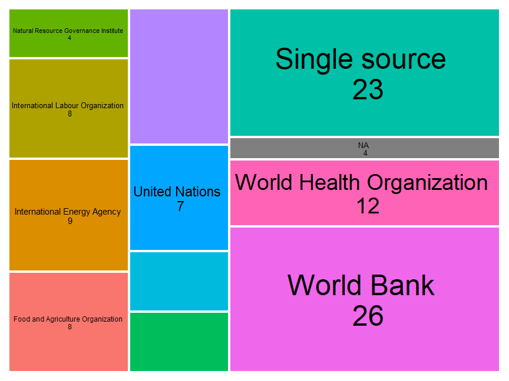

Distribution of ESG indicators by source

## 2.3 Data Management

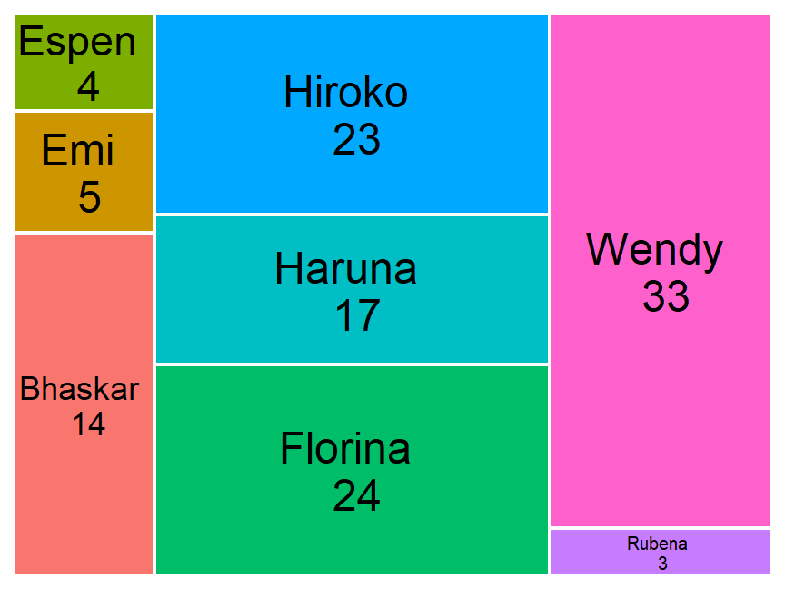

Indicators per manager

## 2.4 Unavailable data

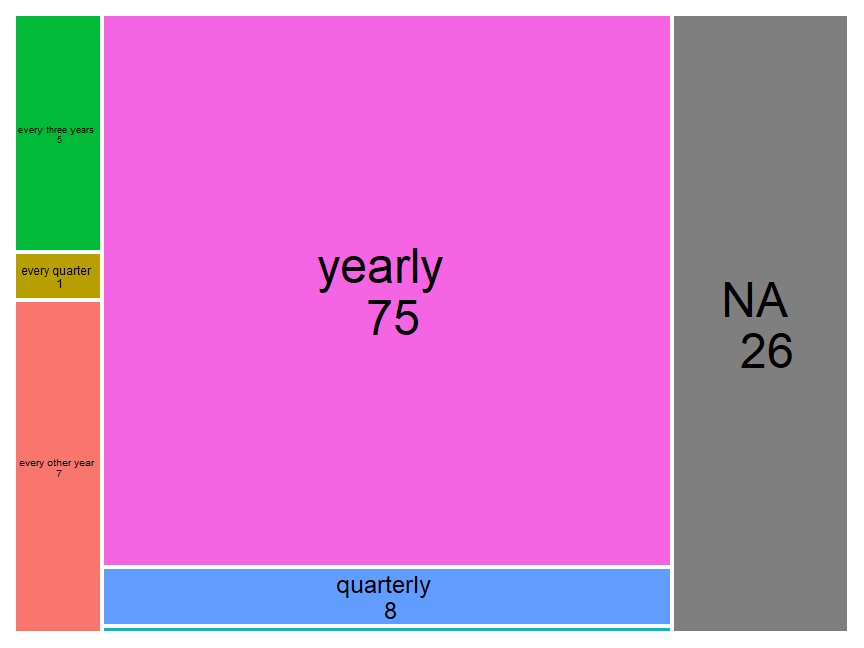

Not Available Indicators

While in the previous we provided a full database description and an overview of the data managers and the type of indicators they are managing, including a classification for ESG purposes, in this section, we overview the indicators that are no longer updated by the WDI team. Following the interviews with the data managers, we identified a total of 26 out of 123 indicators, 21%, that are no longer updated. We classified them as not available(`NA`). 17 of these indicators are environmental indicators. Of these 17 indicators, four of them have not been retrieved in the WDI database. There are the following ones: Genuine savings: energy depletion (% of GDP); Natural capital, subsoil assets: coal (constant 2014 US); Natural capital, subsoil assets: gas (constant 2014 US); Natural capital, subsoil assets: oil (constant 2014 US$). These are all indicators produced by the World Bank and the natural capital ones stem from the following publication: The Changing Wealth of Nations 2018: Building a Sustainable Future. The rest of environmental indicators that are no longer updated are indicators that have been pulled once for a specific purpose (e.g MDG, SDG), indicators with one data point only and indicators that are discontinued. Two CO2 indicators managed by Wendy and produced by the Carbon Dioxide Information Analysis Center are no longer updated by the original source and according to discussions in the department will be replace by IEA provided indicators. A number of four indicators managed by Bhaskar were not wrongly assigned to his team as per our discussion the IT team is managing the datasets. Finally, of these 4 indicators one of them, Adjusted savings: energy depletion (% of GNI), is managed by someone else according to Bhaskar. A number of three social indicators are either discontinued or decommissioned. Six governance indicators are with missing information due to them not being in the WDI database, the assigned data manager is not correctly assigned or there is indication by the data manager of better available data. Finally, a couple of them are not in the WDI database.

## 2.5 ESG indicators broken down

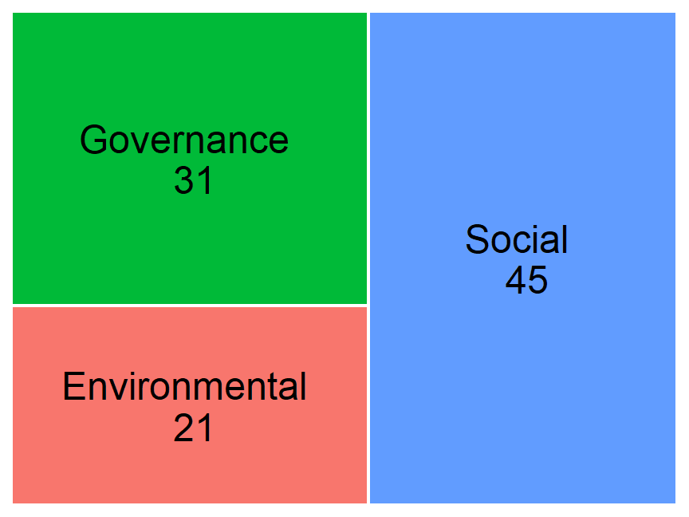

Class of indicators after removing NAs

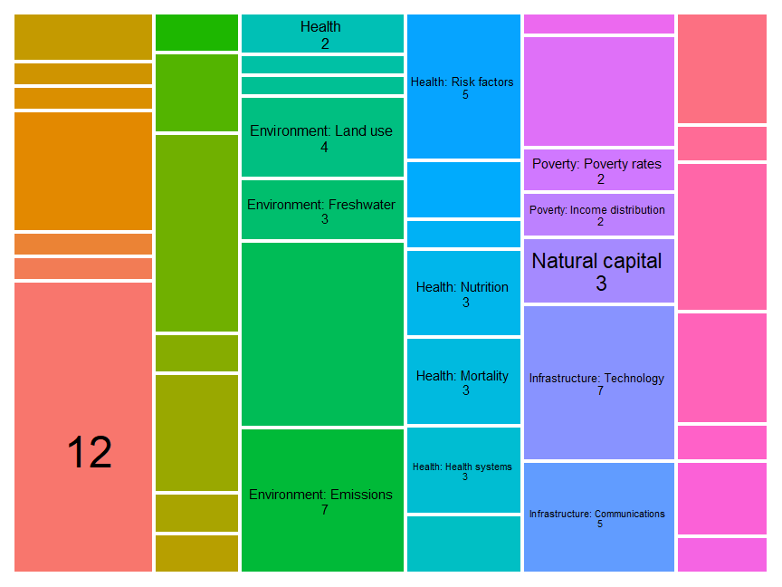

Topic description

Given the previous analysis of the indicators that are not available indicators (NAs), we are left with a total of 97 indicators to perform further analysis. A total of 21 environmental indicators are left from an initial batch of 38 indicators. This is by far the highest rate of attrition observed in the indicators as 45% of the initial set of indicators appears to be no longer updated. *The environmental part of the new ESG database will thus need the largest amount of attention to understand the reasons of the mismatch between original set of indicators and the ones left after the analysis on their status*. 31 governance indicators are left of a total of 37 original one representing a 16% attrition rate. Finally, social indicators appear to be the most robust class of indicators with 45 out of 48 original ones remaining equivalent of a 6% attrition rate. The process of assigning indicators followed an analysis of the description of indicators found in the metadata by name and assigned category. Indicators such as those related to debt, tax, growth and GDP are grouped under governance indicators as one can argue that their evolution is a function of the governance structures in the specific countries.

The assignment of indicators to ESG categories was performed by analyzing the Topic column of the indicators metadata. 29 indicators are related to Environment; 21 to health; 13 to Economic Policy and Debt; 12 to Infrastructure and 11 to Social Protection. 14 indicators are grouped under the category other.

## 2.6 Data collection

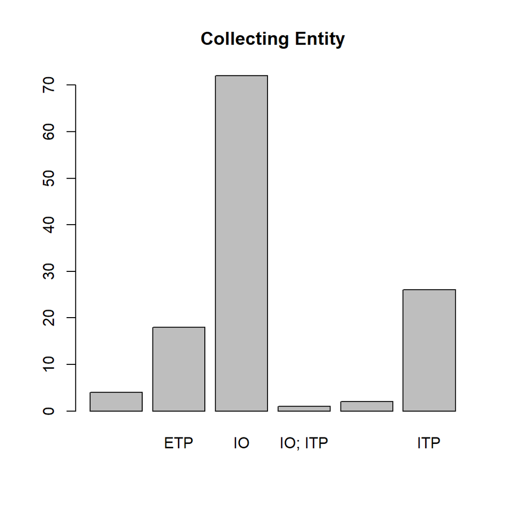

Collecting Entity Type

## 2.7 Data processing

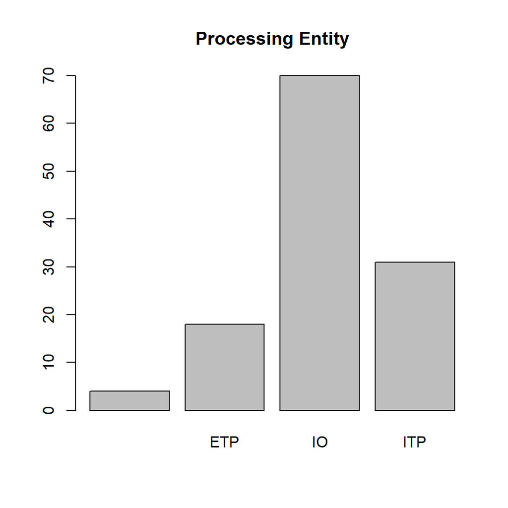

Processing Entity Type

In order to have a comprehensive overview of the indicators, we wanted to capture data on the processing entities of the indicators in order to see if there are any differences between collecting and processing entities. 66 indicators out of 97 are processed by IO of which 12 are environmental, 14 are governance indicators and 40 are social indicators. 10 indicators are processed by external third parties of which one is a social indicator, 5 are governance indicators and 4 are environmental ones. Finally 21 indicators are processed by ITP, internal third parties of which 5 are environmental, 12 are governance indicators, and 4 are social indicators. The small differences between the number of indicators processed by one of the three entity types when compared to the number of indicators collected by the three entity types is given by indicators that have a consortium as collecting entities and a single entity processing the data.

## 2.8 Data dissemination

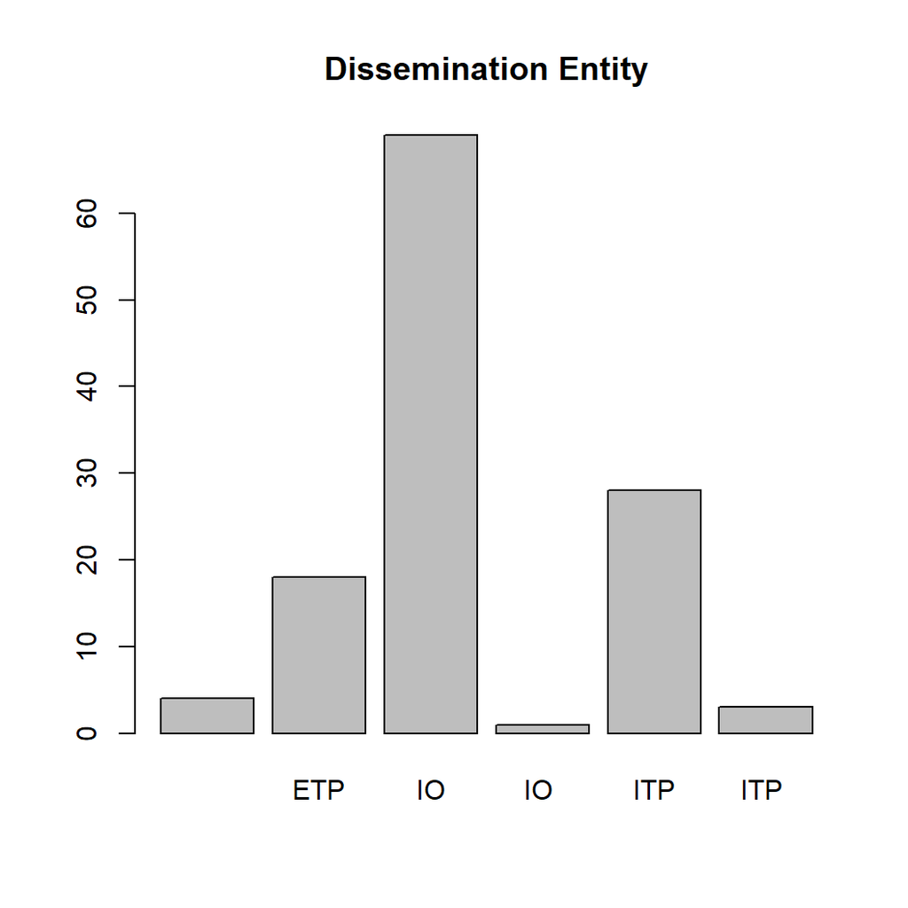

Dissemination entity

We conclude this part of the analysis by looking at the type of disseminating entities. We have again 66 indicators that are disseminated by IOs, with the same class structure observed in the data processing item in terms of environmental, social and governance category. We also observe 10 indicators that are disseminated by external third parties and 21 indicators that are disseminated by World Bank internal third parties. Finally, the structure of entity types for all three categories, collection, processing and dissemination is very robust with IOs dominating these categories followed by World Bank internal parties. Given this situation, there is a high degree of trust placed in these indicators. The downside is that the time lag and update processes are quite high as IOs strive to supply a high accuracy of data, most of the time meaning that they release country level data at year minus one or even year minus two for mor difficult datasets such as CO2 emissions.

## 2.9 Highest Frequency Production

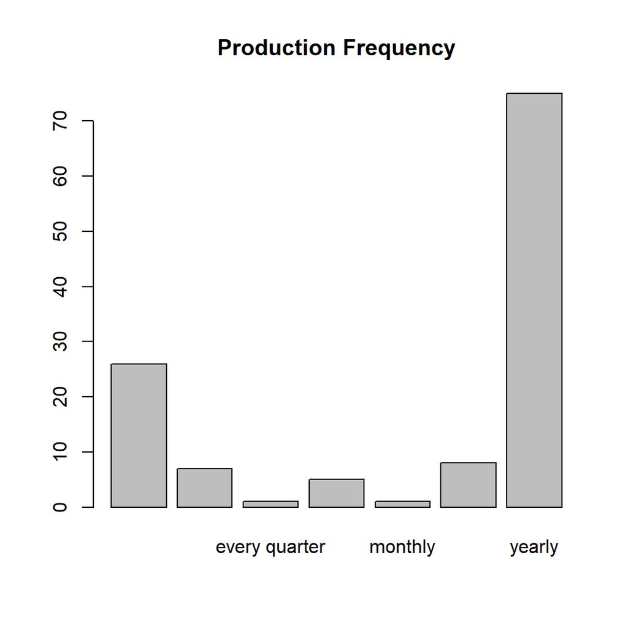

Production frequency

Our next piece of analysis refers to the frequency of production of these indicators by the creating entities. We identified 6 categories of frequency production: monthly, quarterly, yearly, every other year and every three years. One social indicator is updated monthly by the producing entity (i.e. collecting entity). A total of 9 indicators are produced on a quarterly basis of which 8 are governance indicators and one is an environmental indicator. Most of the indicators, 75, are updated yearly. Of these, 13 are environmental indicators, 22 are governance indicators, and 40 are social indicators. A number of 7 indicators are updated every other year of which 4 are environmental and 3 social indicators. Finally, 5 indicators are produced every three years. 3 of these are environmental indicators while one each is social and governance respectively.

## 2.10 Highest Frequency Updates

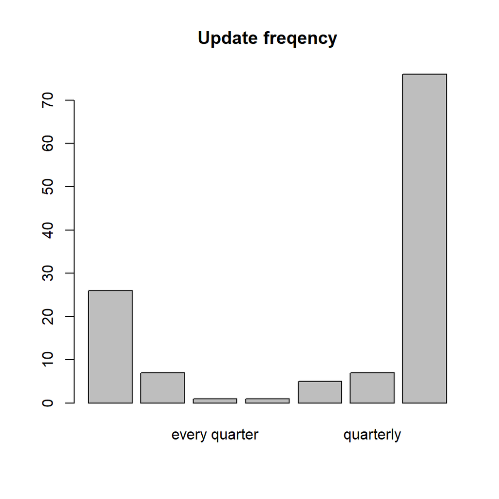

Update frequency

The frequency of updates by the data managers is essential to understand the timeliness of these indicators for external stakeholders. The following covers this part of the database. Firstly, we have 5 categories only for the update frequency as no monthly update occurs in the WDI team. The starting point are quarterly updated. 8 indicators are quarterly updated of which 7 are governance indicators and one environmental. A total of 76 indicators are update by the WDI team. Of these 76 indicators, 13 are environmental, 22 are governance related indicators and 41 are social indicators. Finally, a number of 12 indicators are updated by the WDI team every two or three years. Of these 7 are environmental, 4 social and one governance indicator. In the end, the timeline of updates by the WDI team is a function of the data source collectors own timelines and generally the WDI updates mirror the production rhythm imposed by the collecting entity.

## 2.11 Source Instrument

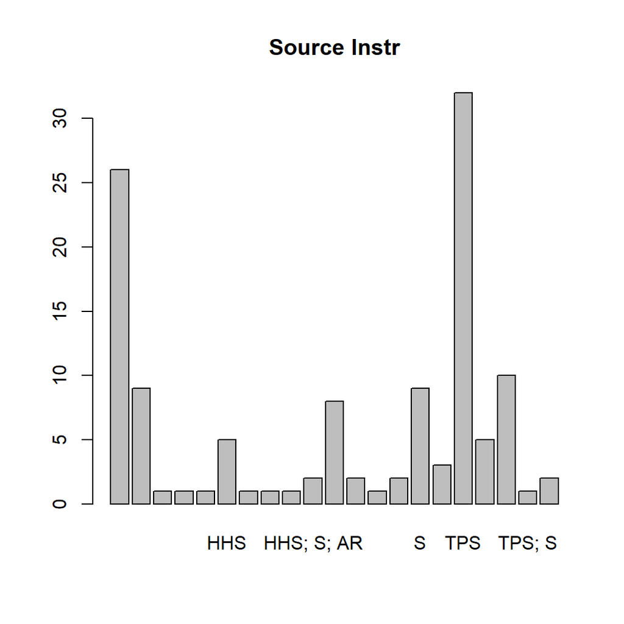

We aimed to provide an analytical overview of the sources through which the data behind the indicators are collected in order to understand better the indicators themselves. These are mostly related to the statistical instruments used to compile the datasets behind the indicators. Our analysis revealed 7 instruments through which the data is collected. These are the following: National accounts (NTA), Household surveys (HHS), Third party sources (TPS), Administrative records (AR), Surveys (S), Sample Registration (SR) and Census (C). 63 indicators only a unique source, either administrative records or surveys, household surveys, third party sources and national accounts. 9 of these indicators are environmental, 27 are social indicators and another 27 are governance indicators. The rest of the 34 indicators have more than one instruments through which data is gathered for the indicators, usually a combination of two or more instruments. 12 of these indicators are environmental, 4 are governance indicators and 18 social indicators. The prevalence of social indicators with more than one statistical instruments as source for data is explained by the complexity of data gathering for social indicators where different sources such as household surveys, administrative records, censuses need to be used to create specific indicators.

## 2.12 Imputation

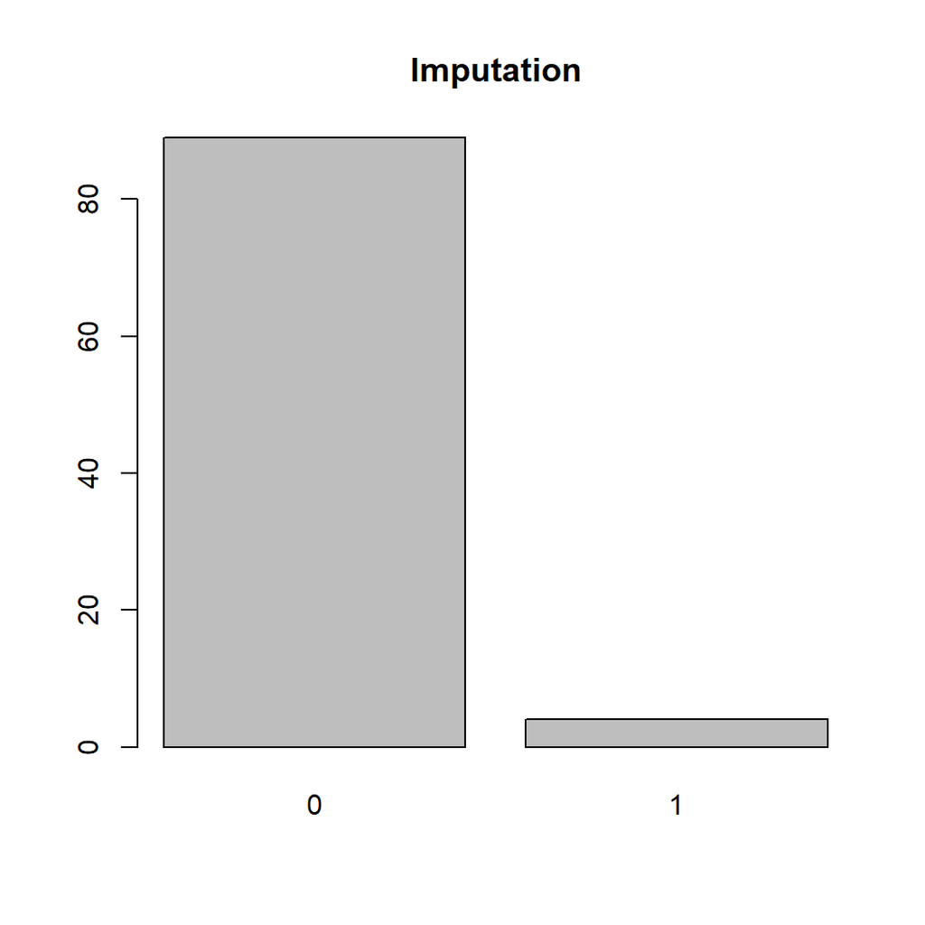

Imputation

There are 4 indicators, 3 social and one governance, out of 97 indicators for which a specific form of gap filling is used, either imputation or a different method. These are the following indicators: Life expectancy at birth, total (years); Mortality rate, infant (per 1,000 live births); Fertility rate, total (births per woman); GNI per capita, Atlas method (current US$). The first three indicators are managed by Emi and the last one by Bhaskar. On the first indicator, an imputation is performed, namely a weighted average between males and females if total estimates is not easily available. On the second one, an interagency effort is conducted to have single point estimated for missing values using regression methods. The work is led by UNICEF and the technical term used for it is smoothing. For the fertility rate indicator, the data manager uses extrapolation for most recent year and interpolations for missing years. Finally, imputation methods are used to complete the GNI per capita indicator.

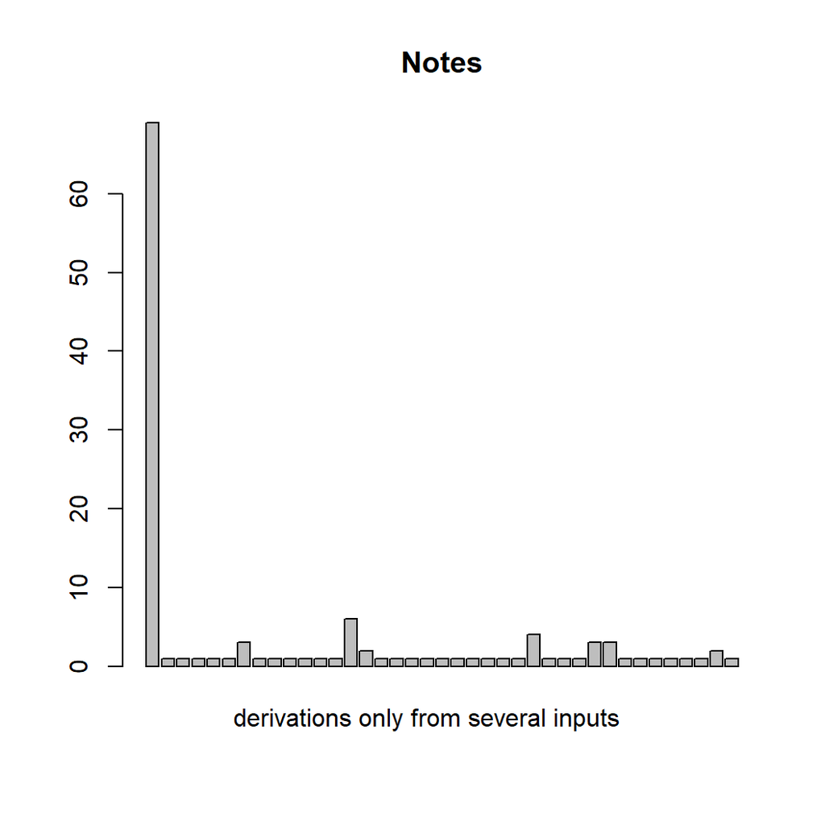

Notes

# 3 Analytical part

## 3.1 Composition of indicators

The composition of the ESG indicators is very heterogeneous and the selection criteria for the indicators have not been fully documented. It seems that the selection of some of the indicators has been made following discussions with stakeholders and investment professionals and based on set of indicators previously used in investment related activities. This blurry selection of indicators may explain in part the high heterogeneity among the ESG, as they vary from from air pollution indicators and number of hot days to political stability and fiscal balance indicators. Ideally, there could be a clear set of criteria to determine whether or not each indicator should enter the final ESG database. In the absence of a clear set of criteria, it is very hard to understand the usefulness of indicators that will enter the ESG database. Having a clear set of criteria to select the indicators in each category of the ESG and determine the relation between indicators and outcomes of interest will make for a better understanding of the database and the selected indicators. Furthermore, it will allow to map specific indicators to investment flows and thus gian a better understanding of how these indicators are used by investment managers and ESG investment services providers.

It is likely that a small number of the current ESG set of indicators is frequently used in ESG investment activities. Currently, one cannot assess which individual indicators are used most frequently thus efforts to improve the database might focus on less used indicators (**I don’t understand this sentence**). An additional piece of research coupled with interviews with investments professionals should provide the analysts with an empirically grounded perspective on the frequency of use of indicators thus efforts to improve the collection and publication timelines of indicators can be allocated more rationally (**I don’t understand. This is precisely the objective of this note.**).

Thus, we suggest the drafting a clear set of criteria for each category of indicators, environmental, social and governance. These criteria should be grounded in extensive research and interviews with ESG investment professionals and ESG data services providers in order to populate the database with the most relevant indicators for these activities. By performing this type of research one can identify additional gaps in the indicators and the needs for new indicators that capture variables of interests to ESG investors.

## 3.2 Missing indicators

Another issue of interest is represented by having 26 out of 123 indicators (21%), or one in five, not being updated by the WDI team. These are assigned Not Available values for the variables of interest in the database. 17 out of these 26 indicators, more than 65%, are environmental indicators while 6 of them are from governance and only three are from the social category. The quality of environmental indicators is questionable as almost 50% of them are missing values. Among these missing values, more than half are sourced from Internal Third Parties at the World Bank, four of which are not in the databank and another four are managed outsite the group of points of consultation or directly by the IT team. Three of these indicators refer to natural capital and are sourced from World Bank publication, *The Changing Wealth of Nations 2018: Building a Sustainable Future*. Another two indicators are sourced from Carbon Dioxide Information Analysis Center, CDIAC, and refer to CO2 indicators. These indicators are no longer updated by the source organization and will be sourced in the future from IEA databases.

There are a total of six governance indicators that come with missing information of which four of them are in another database different from the WDI, according to the POC. Another indicators of this set of six is managed by a different person than the assigned POC and for the final one the POC recommends a better source for the information captured by the indicator, i.e. public debt. Finally, social indicators have the least amount of indicators with missing information, namely three, 2 of them discontinued and one not in the WDI database. We identified 11 sources for these indicators, five of which are international organization and another six are research center or think tanks.

The high number of indicators with missing information on key variables of interest needs to be mitigated by a more through understanding of the usefulness of these indicators, of the exact POC handling the indicators and the reason for their selection into an ESG indicators database. Furthermore, the World Bank can make transparent the reasons for these indicators being no longer updated or inserted in the WDI database and propose candidate indicators to replace these missing information indicators. Finally, the proposed ESG database should not contain indicators that are discontinued or who have unclear use or data managers.

## 3.3 ESG - quality of indicators

Almost 50%, 45 of the 97, indicators that are updated on a regular basis (i.e. not having missing information for key variables in the database) are social indicators. This allows us to infer that social indicators are more robustly managed and more thoroughly updated than all other indicators that currently are proposed for the ESG database. Virtually, all of them are indicators produced by international organizations signaling a correlation between the sources and the robustness of the indicators in terms of their production and dissemination update. Furthermore, virtually all of these indicators have a yearly production cycle by the source organization and a yearly update cycle by the World Bank. As these appear very robust indicators they should take a central place in the ESG database. The World Bank could make a clear case for these indicators being used more widely given their robustness by pointing to their continuous update and the quality of the production entity and the statistical methods used for the creation of the indicators.

A total of 31 indicators out of 97, almost a third, are governance indicators, most of them indicators that deal with economic, financial variables and quality of government among others. More than two thirds of these indicators are updated yearly by the source organization and also yearly by the dissemination entity, the World Bank. The World Bank should explore which of the indicators are most frequently used and assess if a higher production update can be achieved by the source organization. For example, there are 8 indicators that are produced quarterly and at least half of them are amenable to monthly updates cycles. There are 22 indicators that are update yearly and virtually none of them are amenable to a higher production and update frequency. The best avenue of improving these indicators is by understanding the gap from current year to the latest available year in the dataset. Lastly, the vast majority of these indicators are sourced from international organizations which implies a high degree of confidence in the data collection and processing processes.

In conclusion, the vast majority of indicators are produce by international organization. There are a total of 25 unique sources for the 97 indicators of which 19 are international organizations. This implies a high degree of robustness of indicators as indicators produced by international organizations are usually of high quality, abiding by strict statistical standards and are curated thoroughly.

## 3.4 Management of indicators (World Bank vs other organizations)

World Bank produces a total of 16 out of the 97 indicators, most of them governance indicators, 12. Doing Business Report and national accounts data cover more than half of the indicators. The rest of 81 indicators are produced virtually all by international organization pointing to a high overall degree of robustness of indicators and quality. Indicators produced outside of international organizations are more volatile in their production cycles and continuity. Overall, this confers the future ESG database a high quality set of indicators. As a general recommendation, the inclusion of indicators from other sources than international organizations should be carefully assessed as these tend to be more easily discontinued and with less data than indicators produced by international organizations.

The International Energy Agency provides a set of 9 energy related indicators of interest for ESG activities. IEA has strict licensing practices which means that datasets published in the WDI are subject to constraints in terms of what data can be published. Usually, indicators from IEA are lagged one to two years compared to similar indicators published in IEA publications or websites. Negotiating better publication rights with IEA can render the IEA indicators more useful for ESG activities. Alternatively, one can explore the use of energy indicators provided by the United Nations as they have more recent data than the ones IEA allows for publication in the WDI database.

## 3.5 Notes on production and update frequency

# 4 Final remarks and recommendations

Research on the most used indicators out of the 123 indicators proposed needs to be performed in order to assess the degree of use of the indicators for ESG investment activities. This will allow for improvements to the most used indicators.

The identification of gaps in the timeliness of the indicators is essential in order to assess where data for recent years is missing because of licensing and publication rights (e.g. IEA) or data is not available for the more recent years.

# 5 Long and Short Database Overview